# Course Project

Ruomeng Cui

August 17, 2015

## Course Project ### Data Cleaning We first clean the data. We find that a lot of variables have NA or empty-valued for more than 90% of the observations. Moreover, these variables are not correlated with our prediction outcomes. Therefore, we clean the data to remove these variables. This decreases the size of predictors from 159 to 53.

```r
library(caret)
require(caret)
# Load the csv file
train <- read.csv('./pml-training.csv')
# Clean the data:
# We tease out variables with too many NAs and too many missing values
# The reaon is that more than 90% of observations are missing for
# those variables.
complete_variable = vector()
for(name in names(train)) {
  if (sum(complete.cases(train[[name]])) == 19622) {
    if (sum(train[[name]] == "") < 1000) {
      complete_variable <- c(complete_variable, name)
    }
  }
}
#take out time stamps
complete_variable <- c('user_name', complete_variable[8:length(complete_variable)])
train <- train[, complete_variable]
```

Since we have 53 predictors, we preprocess the data to reduce the dimensionality of feathres and highly correlated covariates. We test whether there is any feature with near zero variance and remove it. This is because zero variance indicates almost no relation with the outcome, and thus, very low predicting power.

```r
trainPredictors <- train[, 2:53]
trainOther <- train[, c(54, 1)]
nzv <- nearZeroVar(trainPredictors)
if (length(nzv) != 0) {
  trainPredictors <- trainPredictors[, -nzv]
}
```

Second, we test wehther there is any feature that is a linear combination of other features. We eliminate those features.

```r
lcm <- findLinearCombos(trainPredictors)
if (length(lcm$remove) != 0) {
  trainPredictors <- trainPredictors[, -lcm$remove]
}
```

Last, we remove variables which are highly correlated with each other (correlation > 0.8). We have 46 predictors.

```r
datacor <- cor(trainPredictors)
highCor <- findCorrelation(datacor, cutoff = 0.8)
highCor=highCor[-2]
if (length(highCor) != 0) {
  trainPredictors <- trainPredictors[, -highCor]
}
train <- data.frame(trainOther, trainPredictors)
```

### Model Fitting and Performance Comparison

We preprocess our data by centering them and scaling them. This is because we have a huge discrepency between the scales of different measures. We use accuracy and kappa as our measure of model predictability.

```r
# We use 10-fold cross validation and we repeat it for 10 times.
ctrl <- trainControl(method = 'repeatedcv', repeats = 10, number = 3)
library(MASS)
ldaFit <- train(classe~., method = 'lda', trControl = ctrl,
                data = train, preProc = c("center", "scale"))
library(gbm)
library(plyr)
library(survival)
gbmFit <- train(classe~., method = 'gbm', trControl = ctrl,
                data = train, verbose = FALSE, preProc = c('center', 'scale'))
dtFit <- train(classe~., method = 'rpart', trControl = ctrl,
               data = train, preProc = c('center', 'scale'))
```

This is the performance of all the models:

```r
resamps <- resamples(list(GBM = gbmFit, LDA = ldaFit, DT = dtFit))
summary(resamps)
```

```
##
## Call:
## summary.resamples(object = resamps)
##
## Models: GBM, LDA, DT
## Number of resamples: 30
##
## Accuracy
##       Min. 1st Qu. Median   Mean 3rd Qu.   Max. NA's
## GBM 0.9450  0.9530 0.9545 0.9543  0.9558 0.9621    0
## LDA 0.7092  0.7141 0.7178 0.7173  0.7204 0.7265    0
## DT  0.4885  0.4935 0.4985 0.5110  0.5217 0.5668    0
##
## Kappa
##       Min. 1st Qu. Median   Mean 3rd Qu.   Max. NA's
## GBM 0.9303  0.9405 0.9424 0.9421  0.9441 0.9520    0
## LDA 0.6320  0.6382 0.6427 0.6420  0.6458 0.6536    0
## DT  0.3311  0.3386 0.3447 0.3652  0.3755 0.4556    0
```

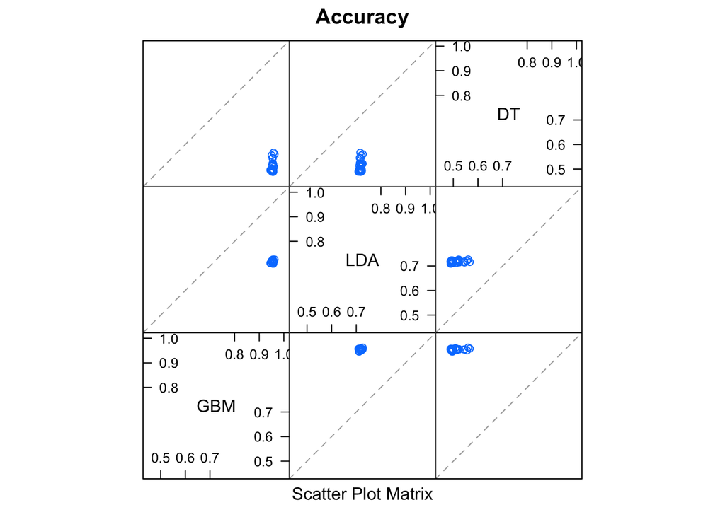

```r
splom(resamps)
```

### Data Prediction

With our final prediction model, we conduct the out-of-sample prediction for the test sets.

```r
test <- read.csv('./pml-testing.csv')
test <- test[, names(train)[2:length(train)]]
pred <- predict(gbmFit, test)
pred
```

```
##  [1] C A B A A E D B A A B C B A E E A B B B
## Levels: A B C D E
```

```r
n <- length(pred)
  for(i in 1:n){
    filename <- paste0("./predictions/problem_id_",i,".txt")
    write.table(pred[i],file=filename,quote=FALSE,row.names=FALSE,col.names=FALSE)
  }
```